# Homework 4

Kent Roller

2024-04-27

7. The built-in PlantGrowth data set contains three different groups, each representing a different plant food diet (you may need to type data(PlantGrowth) to activate it). The group labeled “ctrl” is the control group, while the other two groups are each a different type of experimental treatment. Run the summary() command on PlantGrowth and explain the output. Create a histogram of the ctrl group. As a hint about R syntax, here is one way that you can access the ctrl group data: PlantGrowthweight[PlantGrowth$group==”ctrl”] Also create histograms of the trt1 and trt2 groups. What can you say about the differences in the groups by looking at the histograms?

```r
plant.growth<-PlantGrowth
summary(plant.growth)
```

```
##      weight       group
##  Min.   :3.590   ctrl:10
##  1st Qu.:4.550   trt1:10
##  Median :5.155   trt2:10
##  Mean   :5.073
##  3rd Qu.:5.530
##  Max.   :6.310
```

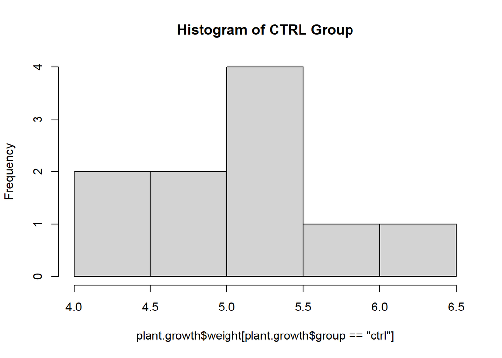

```r
hist.ctrl<-hist(plant.growth$weight[plant.growth$group=='ctrl'], main="Histogram of CTRL Group")
```

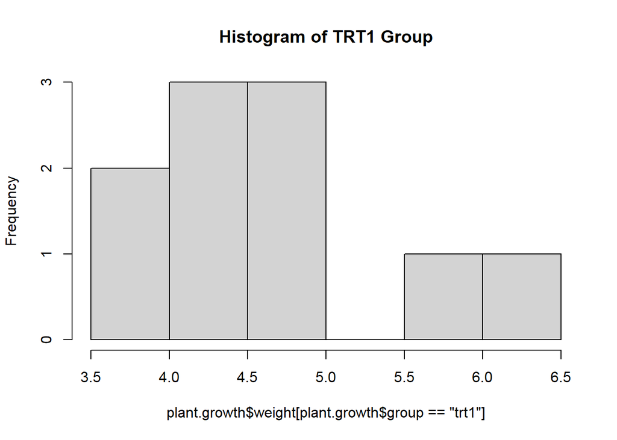

```r
hist.trt1<-hist(plant.growth$weight[plant.growth$group=='trt1'], main="Histogram of TRT1 Group")
```

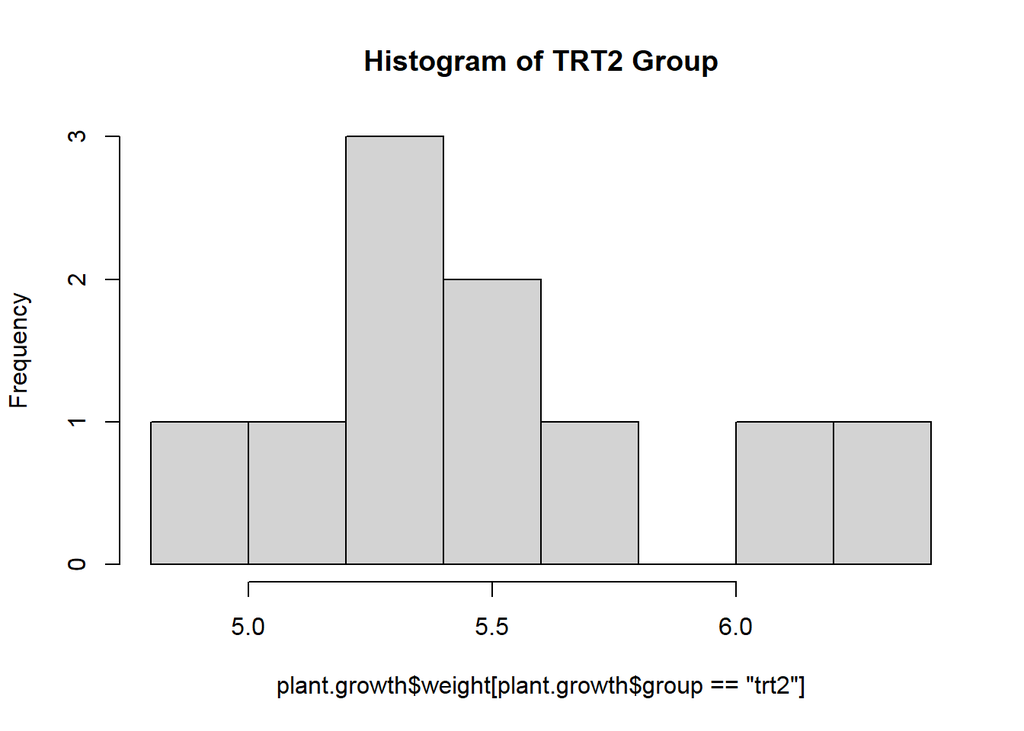

```r
hist.trt2<-hist(plant.growth$weight[plant.growth$group=='trt2'], main="Histogram of TRT2 Group")
```

```r
hist.ctrl
```

```
## $breaks
## [1] 4.0 4.5 5.0 5.5 6.0 6.5
##
## $counts
## [1] 2 2 4 1 1
##
## $density
## [1] 0.4 0.4 0.8 0.2 0.2
##
## $mids
## [1] 4.25 4.75 5.25 5.75 6.25
##
## $xname
## [1] "plant.growth$weight[plant.growth$group == \"ctrl\"]"
##
## $equidist
## [1] TRUE
##
## attr(,"class")
## [1] "histogram"
```

```r
hist.trt1
```

```
## $breaks
## [1] 3.5 4.0 4.5 5.0 5.5 6.0 6.5
##
## $counts
## [1] 2 3 3 0 1 1
##
## $density
## [1] 0.4 0.6 0.6 0.0 0.2 0.2
##
## $mids
## [1] 3.75 4.25 4.75 5.25 5.75 6.25
##
## $xname
## [1] "plant.growth$weight[plant.growth$group == \"trt1\"]"
##
## $equidist
## [1] TRUE
##
## attr(,"class")
## [1] "histogram"
```

```r
hist.trt2
```

```
## $breaks
## [1] 4.8 5.0 5.2 5.4 5.6 5.8 6.0 6.2 6.4
##
## $counts
## [1] 1 1 3 2 1 0 1 1
##
## $density
## [1] 0.5 0.5 1.5 1.0 0.5 0.0 0.5 0.5
##
## $mids
## [1] 4.9 5.1 5.3 5.5 5.7 5.9 6.1 6.3
##
## $xname
## [1] "plant.growth$weight[plant.growth$group == \"trt2\"]"
##
## $equidist
## [1] TRUE
##
## attr(,"class")
## [1] "histogram"
```

The control group seems to have a mean between 5.0 and 5.5 with a somehwat symmetrical bell shaped curve suggesting this may be a normal distribution (further testing required to verify). The histogram of the TRT1 group appears to be much less symmetric without a clear peak suggesting the mean is somewhere between 4.0 and 5.0, a marked differnece from the control. There is also a gap in the observations which may suggest a possible outlier for the group. This is skewed and falls under the category of potentially non normal distribution. The last histogram of TRT2 shows a histogram that looks more normal than TRT1 and looks similar the most similar to the control out of the two test groups. There is less of a skew to this one versus TRT1 which indicates that the skew may not be the result of an outlier as with TRT2.

8. Create a boxplot of the plant growth data, using the model “weight ~ group.” What can you say about the differences in the groups by looking at the boxplots for the different groups?

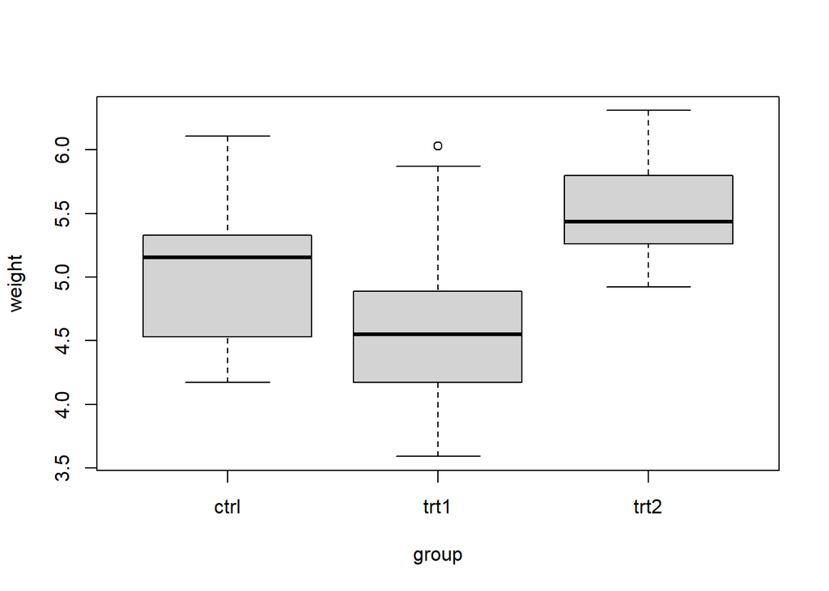

```r
plant.boxplot<-boxplot(weight~group, data=plant.growth)
```

9. Run a t-test to compare the means of ctrl and trt1 in the PlantGrowth data. Report and interpret the confidence interval. Make sure to include a carefully worded statement about what the confidence interval implies with respect to the population mean difference between the ctrl and trt1 groups.

```r
ctrl.v.trt1<-t.test(plant.growth$weight[plant.growth$group=="ctrl"], plant.growth$weight[plant.growth$group=='trt1'])
ctrl.v.trt1
```

```
##
##  Welch Two Sample t-test
##
## data:  plant.growth$weight[plant.growth$group == "ctrl"] and plant.growth$weight[plant.growth$group == "trt1"]
## t = 1.1913, df = 16.524, p-value = 0.2504
## alternative hypothesis: true difference in means is not equal to 0
## 95 percent confidence interval:
##  -0.2875162  1.0295162
## sample estimates:
## mean of x mean of y
##     5.032     4.661
```

The population 95% confidence interval is [-0.28752,1.02952] (*rounded). What this means is that there is a 95% chance that the true population mean difference lies between these two values, and a 5% chance that it is outside this range of values. We can also observe that the confidence interval generated includes zero, which means that there is a possibility that the true mean difference between the two populations is in fact zero, or in other words, there is no statistically significant difference between the two means. This is further verified by the fact that the p-value for this test is well above an alpha of 0.05, further showing that the difference is not statistically significant.

10. Run a t-test to compare the means of ctrl and trt2 in the PlantGrowth data. Report and interpret the confidence interval.

```r
ctrl.v.trt2<-t.test(plant.growth$weight[plant.growth$group=="ctrl"], plant.growth$weight[plant.growth$group=='trt2'])
ctrl.v.trt2
```

```
##
##  Welch Two Sample t-test
##
## data:  plant.growth$weight[plant.growth$group == "ctrl"] and plant.growth$weight[plant.growth$group == "trt2"]
## t = -2.134, df = 16.786, p-value = 0.0479
## alternative hypothesis: true difference in means is not equal to 0
## 95 percent confidence interval:
##  -0.98287213 -0.00512787
## sample estimates:
## mean of x mean of y
##     5.032     5.526
```

Here we can see the 95% confidence interval generated is [-0.98287212,-0.00512787]. This is in contrast to the previous confidence interval as it does not include zero. However, this confidence interval has the same meaning as the last, that is, there is a 95% chance the true mean difference exists within this confidence interval and a 5% chance it does not. The fact that zero is not contained within the interval suggest that this mean difference is statistically significant. This is further backed up by the p-value for the test which is 0.0479 which is just under our alpha level of 0.05 (for a 95% confidence interval) which also suggest the mean difference between the control group and TRT2 is statistically significant.